# Introduction to Churn

Customer churn is one of the main issues in fields such as telecommunications, internet service providers, e-commerce, marketing, or banking. In the telecomunication industry, the market is saturated, making it very difficult to attract new customers. On the customer side, it is very easy to switch to a new provider if it provides a more beneficial offer (Canale and Lunardon, 2014). Because of this saturated market, the cost of aquiring new customers can be five to six times higher than retaining existing customers. Therefore, companies might be best invested in developing customers’ trust on the service rather than attracting new customers.

Researches on predicting customer churn have been done to try to predict whether a customer is likely to quit the service of their service provider and join a different one. Having an understanding of the influential factors causing customer churns on the service can help companies understand customers’ needs and adjust on their provided services based on these factors to reduce churn.

A lot of classification methods have been used to predict the rate of churn. One of those is logistic regression.

The hypothesis for the following project is that given the same data set, all methods if accurated performed should yield similar results. All of these models will have the same question, which is, what predictive models perform the best among the models used in this project to predict the churn rate in the telecom industry. I hypothesize that complex models do not necessarily perform better than simplier models.

# The description of the data set

- Customers’ personal characteristis such as their gender, whether they have a partner, their tenure status, whether they are senior citizens.
- There usage behaviors such as phone service, internet service, online security, tech support, streaming TV, streaming movies, contract, payment method and their month charges.

Both of these types of variables are beneficial for our predictive analysis. It helps us to detect whether their decisions to churn is based on personal characteristics or on their service usage behaviors.

# Method

Some of them will be implemented as black box, meaning I cannot know very well what are the processes they do the analysis on. Therefore, I will choose the dive deep into logistic regression and see if they are well performed. I choose logistic regression particularly because it is one of the models easiest to explain and measure performance.

Bear in mind that these models will be briefly explained instead of looking into details. Specifically, I will mention its advantages and disadvantages of each of these models, then I will explain the steps I did to get the final results.

# EDA

We need some setup for our analysis. To do this, we need the simpleSetup package, which help us to install and load packages at the same time, in case we have not installed packages. This helps to foster reprocibility.

```r
library(simpleSetup)

# SETUP-------

# this package helps to install and load packages at the same time.
library(simpleSetup)

# Load packages, install if needed
packages <- c('tidyverse', 'skimr', "GGally", "purrr", "repurrrsive",
              "nycflights13","gmodels", "stringr", "DataExplorer",
              "summarytools", "recipes", "broom", "modelr", "magrittr",
              "corrr", "viridis", "readr", "caret", "forcats", "tidyquant",
              "caret", "forcats", "tidyquant",
              # for decision tree
              "rpart", "rpart.plot", "ipred", "rsample")
library_install(packages)

churn <- read_csv("../data/WA_Fn-UseC_-Telco-Customer-Churn.csv")
```

For initial modelling process, it is helpful to split the dataset into two parts, one is for training the data, another one is for testing. I created the parition of 0.7 of the whole dataset, using the stratified sampling method.

We also drop `customerID` column because this unique ID does not give us any useful information.

```r
set.seed(123)

train.index <- createDataPartition(churn$Churn, p = 0.7, list = FALSE)
train <- churn[train.index, ]
test <- churn[-train.index, ]

test %<>% select(-customerID) %>% drop_na()

train %<>% select(-customerID) %>% drop_na()
```

# Feature Engineering

Several steps should be taken in order to transform the dataset into workable formats.

1. First, we define Churn as our response variable.
2. We dummy code all columns having nominal values.
3. We tranformed skewed distribution into lookable formats that look like normal distribution.

To do this efficiently, we use `recipes` package, which helps us to prepare and bake those transformations quick and efficiently. The tranformed datasets are stored in bakedTrain and bakedTest.

```r
recObj <- recipe(Churn ~ ., data = train) %>% # chose Churn as the response variable and the rest are explainatory variables
  step_dummy(all_nominal()) %>% # convert string to factor
  step_BoxCox(all_numeric()) %>%
  #step_discretize(all_numeric(), options = list(min_unique = 1)) %>%
  prep(data = train) # prepare for this data

bakedTrain <- bake(recObj, new_data = train) # use bake to transform according to recipes
bakedTest <- bake(recObj, new_data = test)
```

# Perform Logistic Regression

Logistic Regression helps us to predict binary categorical variable. This means that given all inputs of the function, the output would result in either 1 or 0.

We use `glm` function and specifies the family as `binomial` to indicates we want to use logistic regression for the following dataset.

For our problem, since we need to predict churn in terms of multiple predictor variables, we will use multiple logistic regression for our analysis.

```
Call:
glm(formula = Churn_Yes ~ ., family = "binomial", data = bakedTrain)

Deviance Residuals:
    Min       1Q   Median       3Q      Max
-2.1435  -0.6612  -0.3003   0.5714   3.1078

Coefficients: (7 not defined because of singularities)
                                       Estimate Std. Error z value
(Intercept)                            0.982230   1.116783   0.880
SeniorCitizen                          0.150355   0.102517   1.467
tenure                                 0.032609   0.083232   0.392
MonthlyCharges                        -0.009292   0.053604  -0.173
TotalCharges                          -0.142446   0.048748  -2.922
gender_Male                            0.003564   0.078535   0.045
Partner_Yes                            0.115215   0.093912   1.227
Dependents_Yes                        -0.226592   0.107869  -2.101
PhoneService_Yes                      -0.079609   0.793749  -0.100
MultipleLines_No.phone.service               NA         NA      NA
MultipleLines_Yes                      0.482865   0.210403   2.295
InternetService_Fiber.optic            1.354134   0.947521   1.429
InternetService_No                    -1.363310   1.030520  -1.323
OnlineSecurity_No.internet.service           NA         NA      NA
OnlineSecurity_Yes                    -0.150122   0.213306  -0.704
                                      Pr(>|z|)
(Intercept)                            0.37912
SeniorCitizen                          0.14247
tenure                                 0.69522
MonthlyCharges                         0.86237
TotalCharges                           0.00348 **
gender_Male                            0.96380
Partner_Yes                            0.21988
Dependents_Yes                         0.03567 *
PhoneService_Yes                       0.92011
MultipleLines_No.phone.service              NA
MultipleLines_Yes                      0.02174 *
InternetService_Fiber.optic            0.15297
InternetService_No                     0.18586
OnlineSecurity_No.internet.service          NA
OnlineSecurity_Yes                     0.48157
 [ reached getOption("max.print") -- omitted 16 rows ]
---
Signif. codes:  0 '***' 0.001 '**' 0.01 '*' 0.05 '.' 0.1 ' ' 1

(Dispersion parameter for binomial family taken to be 1)

    Null deviance: 5701.5  on 4921  degrees of freedom
Residual deviance: 4026.8  on 4898  degrees of freedom
AIC: 4074.8

Number of Fisher Scoring iterations: 6
```

```
# A tibble: 24 x 5
   term              estimate std.error statistic p.value
   <chr>                <dbl>     <dbl>     <dbl>   <dbl>
 1 (Intercept)        0.982      1.12      0.880  0.379
 2 SeniorCitizen      0.150      0.103     1.47   0.142
 3 tenure             0.0326     0.0832    0.392  0.695
 4 MonthlyCharges    -0.00929    0.0536   -0.173  0.862
 5 TotalCharges      -0.142      0.0487   -2.92   0.00348
 6 gender_Male        0.00356    0.0785    0.0454 0.964
 7 Partner_Yes        0.115      0.0939    1.23   0.220
 8 Dependents_Yes    -0.227      0.108    -2.10   0.0357
 9 PhoneService_Yes  -0.0796     0.794    -0.100  0.920
10 MultipleLines_Yes  0.483      0.210     2.29   0.0217
# ... with 14 more rows
```

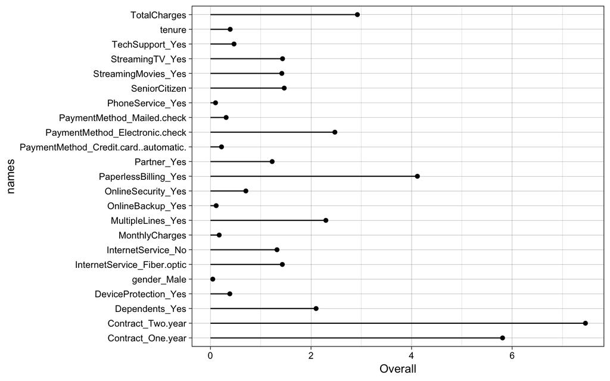

The following graph shows the importance of specific predictors influencing the outcome. The most important predictor is `Two year Contract`, following that are `One year contract`, and `Paperless Billing`.

Our following model is then used to predict the test dataset to see how much can the train dataset predict when it comes to new entries.

What we might want to know is the error rate or the model. Our model error shows `0.19`. This error rate is not the best, but we also recognize that no model can have no errors.

```
# A tibble: 1 x 1
  m1.error
     <dbl>
1    0.194
```

The problem we might face from running multiple logistic regression is counfounding, in which there are correlations among predictors.

## Model Performance using ROC curve

The graphic shows the tradeoff between the rate at which the model correctly predict something and the rate of incorrectly predicting something.

The result shows AUC score equals **0.85**. The AUC is the area under the ROC curve and ranges from 0.5 to 1. If the value is above 0.8, this indicates that the model is performing well to discriminate between categories comprising our response variable.

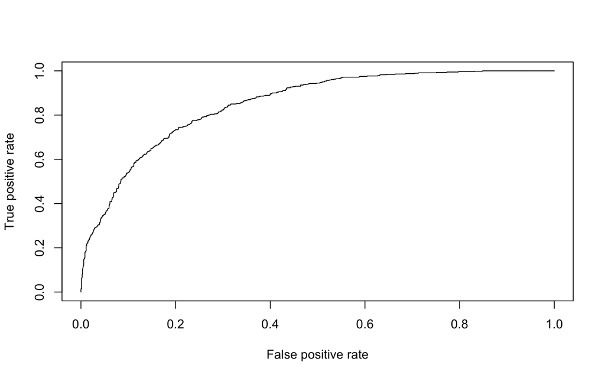

```
[[1]]
[1] 0.8503479
```

# Decision Trees

Decision trees divide the data set into smaller groups and fit a simple model to each group. This partitioning process uses successive binary partitions based on different explainatory variables. The result is based on the average response values of all observations in the smaller group.

The model starts by looking at the entire data set and searches every instance of distinct value of every input variable to find a predictor and split value that partitions the data into two regions. The goal is to minimize the overall sums of squares error.

Once we found the best splot, we split the data into two resulting regions and repeat the splitting process on each of the two regions. The process stops once it reaches its limit. However, while it can produce a very complex trees and makes very good predictions on the training data, it tend to overfit and lead to poor performance on unseen data.

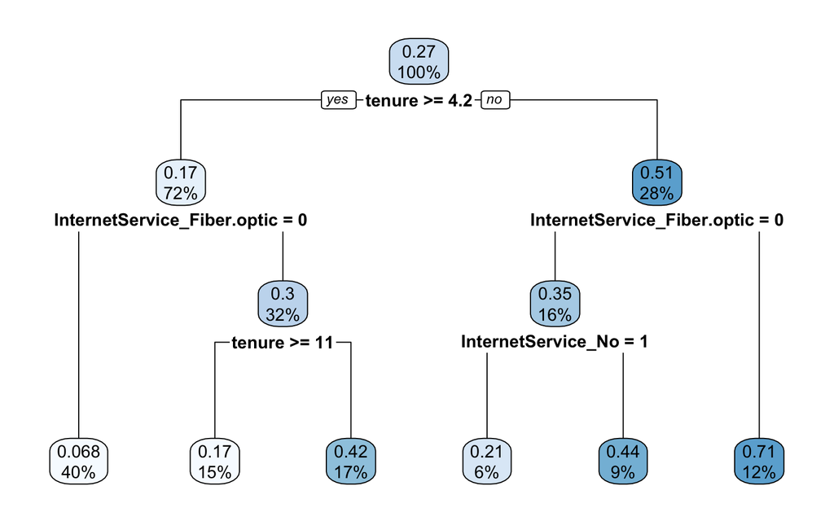

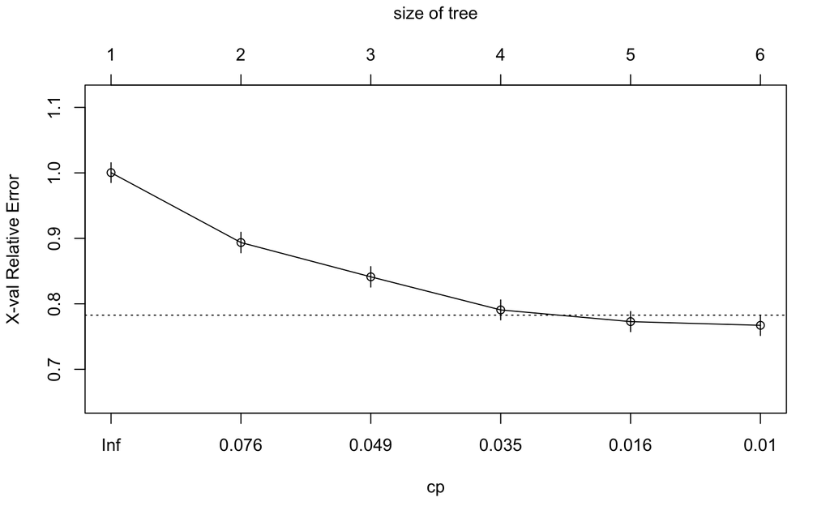

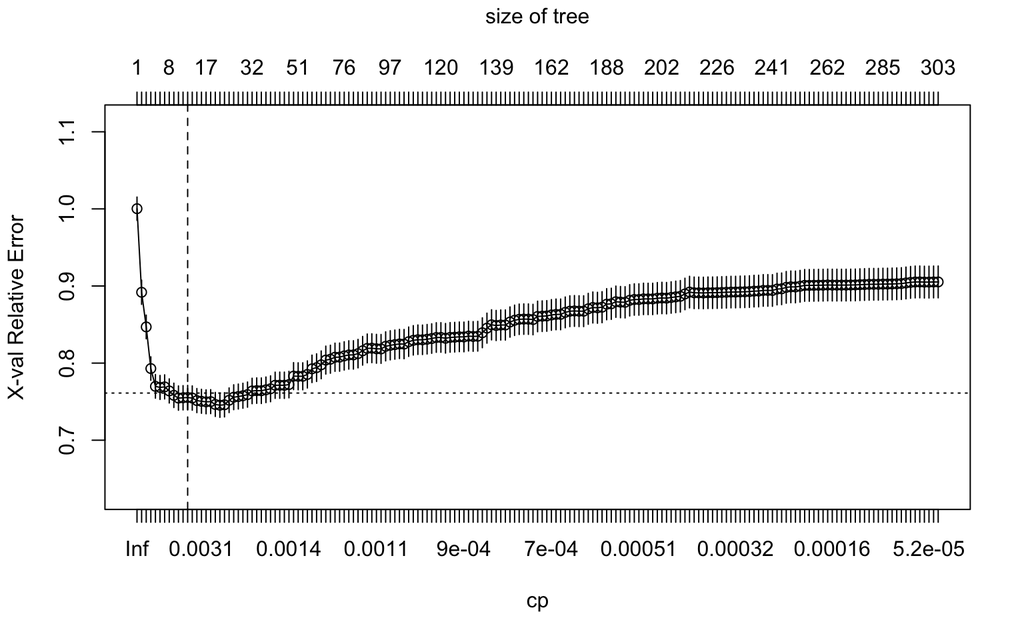

```
          CP nsplit rel error    xerror       xstd
1 0.11414153      0 1.0000000 1.0003442 0.01510652
2 0.05091421      1 0.8858585 0.8936271 0.01567402
3 0.04782354      2 0.8349443 0.8412396 0.01562977
4 0.02597188      3 0.7871207 0.7907356 0.01523350
5 0.01022392      4 0.7611488 0.7728649 0.01535470
6 0.01000000      5 0.7509249 0.7672076 0.01553731
```

```
          CP nsplit rel error    xerror       xstd
1 0.11414153      0 1.0000000 1.0004123 0.01510757
2 0.05091421      1 0.8858585 0.8955207 0.01570307
3 0.04782354      2 0.8349443 0.8399519 0.01551935
4 0.02597188      3 0.7871207 0.7956633 0.01522040
5 0.01022392      4 0.7611488 0.7708854 0.01524531
6 0.01000000      5 0.7509249 0.7702334 0.01542749
```

```
  minsplit maxdepth
1        5        8
2        6        8
3        7        8
4        8        8
5        9        8
6       10        8
```

```
[1] 128
```

```
  minsplit maxdepth   cp     error
1       20        8 0.01 0.7597369
2       16       12 0.01 0.7618560
3       16       15 0.01 0.7624504
4        8       11 0.01 0.7625245
5       10       15 0.01 0.7626769
```

```
[1] 0.3878063
```

```
Bagging regression trees with 25 bootstrap replications

Call: bagging.data.frame(formula = Churn_Yes ~ ., data = bakedTrain,
    coob = TRUE)

Out-of-bag estimate of root mean squared error:  0.3817
```

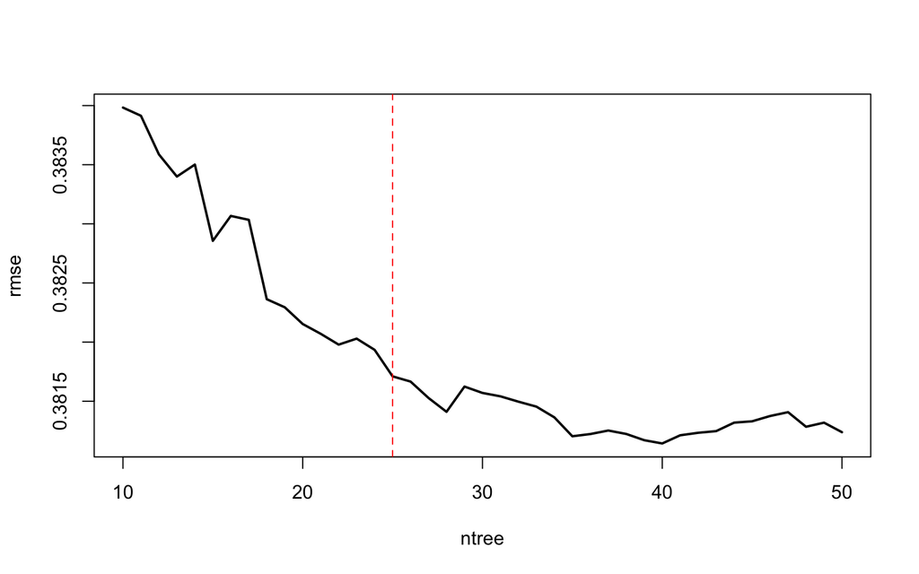

```
Bagged CART

4922 samples
  30 predictor

No pre-processing
Resampling: Cross-Validated (10 fold)
Summary of sample sizes: 4429, 4430, 4430, 4430, 4430, 4430, ...
Resampling results:

  RMSE       Rsquared   MAE
  0.3805366  0.2579772  0.2933539
```

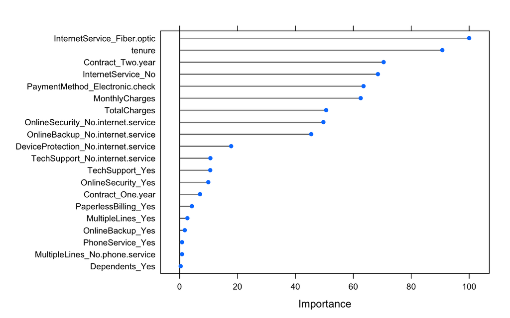

```
[1] 0.3812741
```

# Limitations and further study

2018-12-17